# CollegeThree

Yakovlev D.M.

2024-12-11

# Об анализе зависимостей

Воспользуемся полученными в первой части задания результатами.

```r
library(readxl)
col_I_sn<-read_excel("stat2021_sm\\us_col.std\\I_shortname.xls")
col_I<-read_excel("stat2021_sm\\us_col.std\\I.xls")
col_I_sn$PPIND=ifelse(col_I_sn$PPIND==1, "public", "private")
head(col_I_sn)|>rmarkdown::paged_table()
```

| ...1 | PPIND | FICE | STATE | TYPE | AVRMATH | AVRVERB | AVRCOMB | AVR_ACT | MATH_1 | MATH_3 | VERB_1 | VERB_3 | ACT_1 | ACT_3 | APP_REC | APP_ACC | NEW_STUD | NEW10 | NEW25 | FULLTIME | PARTTIME | IN_STATE | OUT_STAT | R_B_COST | ROOM | BOARD | ADD_FEE | BOOK | PERSONAL | … |
| --- | --- | --- | --- | --- | --- | --- | --- | --- | --- | --- | --- | --- | --- | --- | --- | --- | --- | --- | --- | --- | --- | --- | --- | --- | --- | --- | --- | --- | --- | --- |
| Auburn University-Ma | public | 1009 | AL | I | 575 | 501 | 1076 | 24 | 520 | 638 | 453 | 559 | 21 | 27 | 7548 | 6791 | 3070 | 25 | 57 | 16262 | 1716 | 2100 | 6300 | 3933 | NA | NA | NA | 600 | 1908 | … |
| University of Alabam | public | 1051 | AL | I | NA | NA | NA | 23 | NA | NA | NA | NA | 20 | 25 | 7593 | 5972 | 2682 | NA | 57 | 13780 | 1599 | 2172 | 5424 | 3530 | 1600 | 1930 | NA | 580 | 1654 | … |
| University of Alabam | public | 1052 | AL | I | NA | NA | NA | 21 | NA | NA | NA | NA | 18 | 24 | 1797 | 1260 | 938 | 24 | 35 | 6960 | 4698 | 2220 | 4440 | 5175 | 1935 | 3240 | 291 | 750 | 2200 | … |
| University of Alaska | public | 1063 | AK | I | 499 | 462 | 961 | 22 | NA | NA | NA | NA | NA | NA | 1852 | 1427 | 928 | NA | NA | 3885 | 4519 | 1742 | 5226 | 3590 | 1800 | 1790 | 155 | 650 | 2304 | … |
| Arizona State Univer | public | 1081 | AZ | I | 521 | 453 | 974 | 23 | 450 | 590 | 390 | 500 | 20 | 25 | 12809 | 10308 | 3761 | 24 | 49 | 22593 | 7585 | 1828 | 7434 | 4850 | NA | NA | 66 | 700 | 2100 | … |
| Northern Arizona Uni | public | 1082 | AZ | I | 495 | 444 | 939 | 22 | 420 | 560 | 380 | 500 | 19 | 24 | 5891 | 4931 | 1973 | 23 | 48 | 11249 | 2682 | 1828 | 6746 | 3728 | 1890 | 1838 | 66 | 620 | 2342 | … |

```r
colNames<-c("ADD_FEE", "BOOK", "R_B_COST","IN_STATE","OUT_STAT","NEW10","AVRCOMB","SF_RATIO","PH_D","GRADUAT","PPIND")
col_I_comp<-col_I_sn[colNames]
```

Выделим основные признаки, по которым будет проходить дальнейший анализ данных

Количественные признаки:

- AVRMATH Average Math SAT score
- AVRVERB Average Verbal SAT score
- AVRCOMB Average Combined SAT score
- AVR_ACT Average ACT score
- MATH_1 First quartile - Math SAT
- MATH_3 Third quartile - Math SAT
- VERB_1 First quartile - Verbal SAT
- VERB_3 Third quartile - Verbal SAT
- ACT_1 First quartile - ACT
- ACT_3 Third quartile - ACT
- APP_REC Number of applications received
- APP_ACC Number of applicants accepted
- NEW_STUD Number of new students enrolled
- FULLTIME Number of fulltime undergraduates
- PARTTIME Number of parttime undergraduates
- IN_STATE In-state tuition
- OUT_STAT Out-of-state tuition
- R_B_COST Room and board costs
- ROOM Room costs
- BOARD Board costs
- ADD_FEE Additional fees
- BOOK Estimated book costs
- PERSONAL Estimated personal spending
- PH_D Pct. of faculty with Ph.D.’s
- TERM_D Pct. of faculty with terminal degree
- SAL_FULL Average salary - full professor
- SAL_AC Average salary - associate professor
- SAL_AS Average salary - assistant professor
- SAL_ALL Average salary - all ranks
- COMP_FUL Average compensation - full professor
- COMP_AC Average compensation - associate professor
- COMP_AS Average compensation - assistant professor
- COMP_ALL Average compensation - all ranks
- NUM_FULL Number of full professor
- NUM_AC Number of associate professor
- NUM_AS Number of assistant professor
- NUM_INS Number of instructors
- NUM_ALL Number of faculty - all ranks
- INSTRUCT Instructional expenditure per student
- GRADUAT Graduation rate
- SF_RATIO Student/faculty ratio
- DONATE Pct.alumni who donate
- NEW10 Pct. new students from top 10% of H.S. class - % студентов из топ 10% своей старшей школы
- NEW25 Pct. new students from top 25% of H.S. class - % студентов из топ 25% своей старшей школы

Качественные признаки:

- FICE - Federal ID Number
- …1 - Название университета
- PPIND Public/private indicator (public=1, private=2)
- STATE State (postal code)
- TYPE - I (можно удалить)

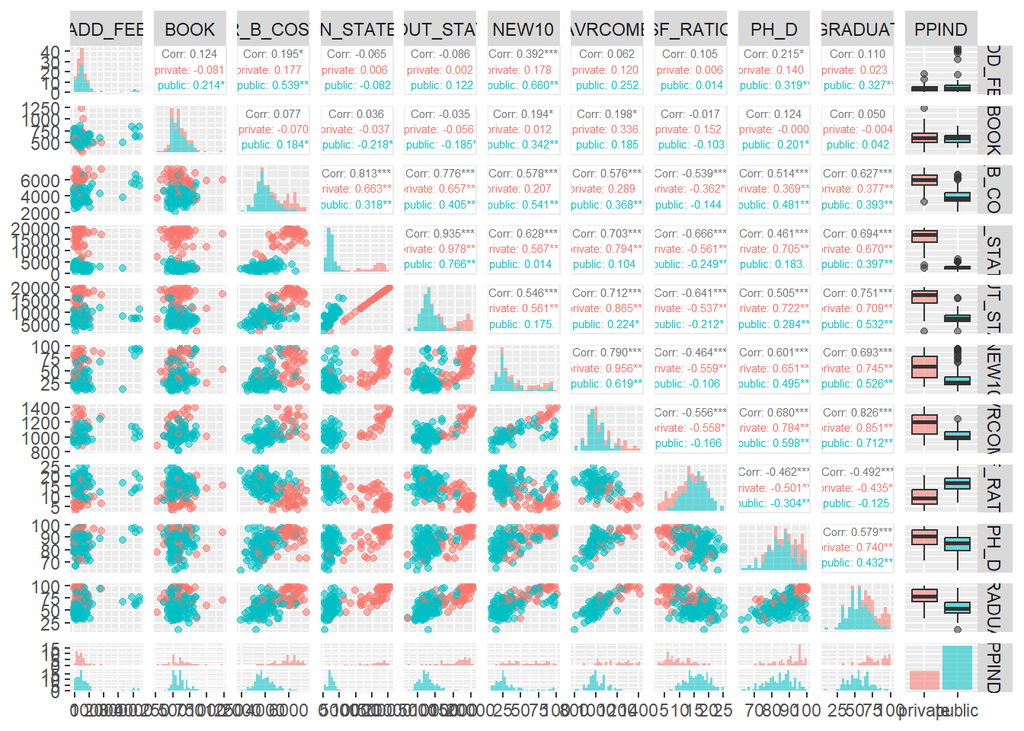

```r
ggpairs(col_I_comp, aes(alpha = 0.5, color=PPIND),
        diag = list(continuous = wrap("barDiag", bins = 20)),
        upper = list(continuous = wrap("cor", size = 2)))
```

Что можно заметить:

- Сильная положительная зависимость GRADUAT от PH_D, AVRCOMP, NEW10, OUT_STAT, R_B_COST, сильная отрицательная от SF_RATIO;

IN_STATE является искусственным параметром, так как зависит от субсидирования штатов (неявная зависимость)

log dataset

```r
q_cols<-sapply(col_I_sn, is.numeric)
q_cols[c("PPIND", "FICE")]<-FALSE
q_cols<-names(q_cols)[q_cols==TRUE]

col_I_sn_log<-col_I_sn|>
  mutate(across(q_cols, ~log(.x)))|>
  rename_with(~paste0("log-", .x), q_cols)
```

Выбранные признаки с разделением по группам

```r
colNames<-c("ADD_FEE", "BOOK", "R_B_COST","OUT_STAT","NEW10","AVRCOMB","SF_RATIO","PH_D","GRADUAT", "PPIND")
colFin<-c("ADD_FEE", "BOOK", "PPIND")
colCost<-c("R_B_COST", "OUT_STAT", "PPIND")
colNew<-c("AVRCOMB", "PPIND")
colStud<-c("SF_RATIO", "PH_D", "NEW10", "GRADUAT", "PPIND")
col_I_comp<-col_I_sn[colNames]
head(col_I_comp)|>rmarkdown::paged_table()
```

| ADD_FEE | BOOK | R_B_COST | OUT_STAT | NEW10 | AVRCOMB | SF_RATIO | PH_D | GRADUAT | PPIND |
| --- | --- | --- | --- | --- | --- | --- | --- | --- | --- |
| NA | 600 | 3933 | 6300 | 25 | 1076 | 16.7 | 85 | 69 | public |
| NA | 580 | 3530 | 5424 | NA | NA | 17.3 | 80 | 50 | public |
| 291 | 750 | 5175 | 4440 | 24 | NA | 6.7 | 96 | 33 | public |
| 155 | 650 | 3590 | 5226 | NA | 961 | 10.0 | 67 | NA | public |
| 66 | 700 | 4850 | 7434 | 24 | 974 | 18.9 | 88 | 48 | public |
| 66 | 620 | 3728 | 6746 | 23 | 939 | 21.7 | 78 | 41 | public |

```r
log_colNames<-c(paste0("log-", colNames)[-length(colNames)], "PPIND")
log_colFin<-c(paste0("log-", colFin)[-length(colFin)], "PPIND")
log_colCost<-c(paste0("log-", colCost)[-length(colCost)], "PPIND")
log_colNew<-c(paste0("log-", colNew)[-length(colNew)], "PPIND")
log_colStud<-c(paste0("log-", colStud)[-length(colStud)], "PPIND")
col_I_comp_log<-col_I_sn_log[log_colNames]
head(col_I_comp_log)|>rmarkdown::paged_table()
```

| log-ADD_FEE | log-BOOK | log-R_B_COST | log-OUT_STAT | log-NEW10 | log-AVRCOMB | log-SF_RATIO | log-PH_D | log-GRADUAT | PPIND |
| --- | --- | --- | --- | --- | --- | --- | --- | --- | --- |
| NA | 6.396930 | 8.277158 | 8.748305 | 3.218876 | 6.981006 | 2.815409 | 4.442651 | 4.234107 | public |
| NA | 6.363028 | 8.169053 | 8.598589 | NA | NA | 2.850707 | 4.382027 | 3.912023 | public |
| 5.673323 | 6.620073 | 8.551595 | 8.398410 | 3.178054 | NA | 1.902108 | 4.564348 | 3.496508 | public |
| 5.043425 | 6.476972 | 8.185907 | 8.561401 | NA | 6.867974 | 2.302585 | 4.204693 | NA | public |
| 4.189655 | 6.551080 | 8.486734 | 8.913819 | 3.178054 | 6.881411 | 2.939162 | 4.477337 | 3.871201 | public |
| 4.189655 | 6.429719 | 8.223627 | 8.816705 | 3.135494 | 6.844815 | 3.077312 | 4.356709 | 3.713572 | public |

```r
col_I_mixed<-col_I_comp|>mutate(ADD_FEE=col_I_comp_log$`log-ADD_FEE`)|>rename(`log-ADD_FEE`=ADD_FEE)
head(col_I_mixed)|>rmarkdown::paged_table()
```

| log-ADD_FEE | BOOK | R_B_COST | OUT_STAT | NEW10 | AVRCOMB | SF_RATIO | PH_D | GRADUAT | PPIND |
| --- | --- | --- | --- | --- | --- | --- | --- | --- | --- |
| NA | 600 | 3933 | 6300 | 25 | 1076 | 16.7 | 85 | 69 | public |
| NA | 580 | 3530 | 5424 | NA | NA | 17.3 | 80 | 50 | public |
| 5.673323 | 750 | 5175 | 4440 | 24 | NA | 6.7 | 96 | 33 | public |
| 5.043425 | 650 | 3590 | 5226 | NA | 961 | 10.0 | 67 | NA | public |
| 4.189655 | 700 | 4850 | 7434 | 24 | 974 | 18.9 | 88 | 48 | public |
| 4.189655 | 620 | 3728 | 6746 | 23 | 939 | 21.7 | 78 | 41 | public |

```r
summary(col_I_mixed)
```

```
##   log-ADD_FEE         BOOK           R_B_COST       OUT_STAT
##  Min.   :2.996   Min.   : 300.0   Min.   :2082   Min.   : 2279
##  1st Qu.:5.347   1st Qu.: 500.0   1st Qu.:3588   1st Qu.: 6712
##  Median :6.053   Median : 600.0   Median :4213   Median : 8400
##  Mean   :5.955   Mean   : 603.1   Mean   :4538   Mean   :10108
##  3rd Qu.:6.542   3rd Qu.: 673.8   3rd Qu.:5564   3rd Qu.:12668
##  Max.   :8.383   Max.   :1230.0   Max.   :7425   Max.   :20100
##  NA's   :40      NA's   :2                       NA's   :1
##      NEW10          AVRCOMB        SF_RATIO          PH_D          GRADUAT
##  Min.   : 8.00   Min.   : 810   Min.   : 2.90   Min.   :63.00   Min.   :10.00
##  1st Qu.:24.00   1st Qu.: 980   1st Qu.:10.88   1st Qu.:80.50   1st Qu.:47.50
##  Median :32.00   Median :1017   Median :14.50   Median :87.00   Median :62.00
##  Mean   :41.48   Mean   :1058   Mean   :14.23   Mean   :85.72   Mean   :62.02
##  3rd Qu.:57.00   3rd Qu.:1126   3rd Qu.:18.02   3rd Qu.:92.00   3rd Qu.:74.50
##  Max.   :98.00   Max.   :1410   Max.   :24.70   Max.   :99.00   Max.   :99.00
##  NA's   :16      NA's   :67                     NA's   :9       NA's   :5
##     PPIND
##  Length:176
##  Class :character
##  Mode  :character
##
##
##
##
```

```r
colSums(is.na(col_I_mixed))
```

```
## log-ADD_FEE        BOOK    R_B_COST    OUT_STAT       NEW10     AVRCOMB
##          40           2           0           1          16          67
##    SF_RATIO        PH_D     GRADUAT       PPIND
##           0           9           5           0
```

Анализ линейных зависимостей:

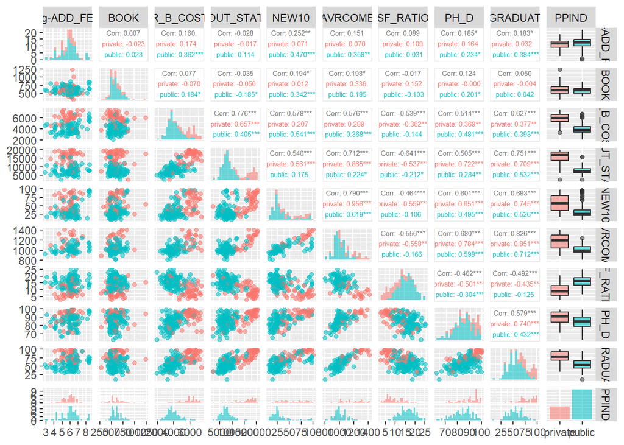

```r
ggpairs(col_I_mixed, aes(alpha = 0.5, color=PPIND),
        diag = list(continuous = wrap("barDiag", bins = 20)),
        upper = list(continuous = wrap("cor", size = 2)))
```

Здесь указываются коэффициенты корреляции Пирсона и их значимость (по числу `*` от менее значимых ``до самых значимых`***`). Можно заметить значимые коэффициенты корреляции, особенно в группе “public”.

```r
col_split_mixed<-split(col_I_mixed, col_I_mixed$PPIND)
names(col_split_mixed)<-c("private", "public")
col_split_mixed<-lapply(col_split_mixed, function(x){
  dplyr::select(x, -PPIND)
})
colMixed<-names(col_I_mixed)
colMixed<-colMixed[-length(colMixed)]
col_split_mixed$private|>rmarkdown::paged_table()
```

| log-ADD_FEE | BOOK | R_B_COST | OUT_STAT | NEW10 | AVRCOMB | SF_RATIO | PH_D | GRADUAT |
| --- | --- | --- | --- | --- | --- | --- | --- | --- |
| 5.347108 | 735 | 5051 | 16695 | 98 | 1410 | 6.5 | NA | 83 |
| NA | 840 | 6795 | 18669 | 88 | 1401 | 9.7 | NA | 96 |
| 5.799093 | 600 | 6482 | 17230 | 45 | 1090 | 11.4 | 90 | 68 |
| 5.799093 | 400 | 4695 | 15192 | 29 | 1010 | 15.9 | 84 | 67 |
| NA | 630 | 6510 | 19840 | 95 | NA | 5.8 | 96 | 99 |
| 6.016157 | 530 | 4230 | 10220 | 22 | 1035 | 18.3 | 82 | 75 |
| 5.347108 | 450 | 6400 | 15934 | 35 | 1133 | 13.6 | NA | 69 |
| 6.131226 | 526 | 6408 | 13712 | 24 | NA | 9.3 | 90 | 75 |
| 6.579251 | 700 | 6328 | 17450 | 38 | NA | 7.6 | 92 | 72 |
| 5.049856 | 670 | 7131 | 18300 | 71 | NA | 7.2 | 91 | 95 |

[output cut: 43 more lines]

```r
col_split_mixed$public|>rmarkdown::paged_table()
```

| log-ADD_FEE | BOOK | R_B_COST | OUT_STAT | NEW10 | AVRCOMB | SF_RATIO | PH_D | GRADUAT |
| --- | --- | --- | --- | --- | --- | --- | --- | --- |
| NA | 600 | 3933 | 6300 | 25 | 1076 | 16.7 | 85 | 69 |
| NA | 580 | 3530 | 5424 | NA | NA | 17.3 | 80 | 50 |
| 5.673323 | 750 | 5175 | 4440 | 24 | NA | 6.7 | 96 | 33 |
| 5.043425 | 650 | 3590 | 5226 | NA | 961 | 10.0 | 67 | NA |
| 4.189655 | 700 | 4850 | 7434 | 24 | 974 | 18.9 | 88 | 48 |
| 4.189655 | 620 | 3728 | 6746 | 23 | 939 | 21.7 | 78 | 41 |
| 4.189655 | 620 | 4216 | 7434 | 29 | 983 | 19.6 | 91 | 49 |
| 4.804021 | 500 | 3300 | 5028 | 25 | NA | 14.8 | 73 | 39 |
| NA | 636 | 6246 | 11648 | 95 | 1218 | 15.8 | 93 | 78 |
| 8.383433 | 841 | 5285 | 7699 | 95 | 1070 | 14.5 | NA | 76 |

[output cut: 113 more lines]

Private:

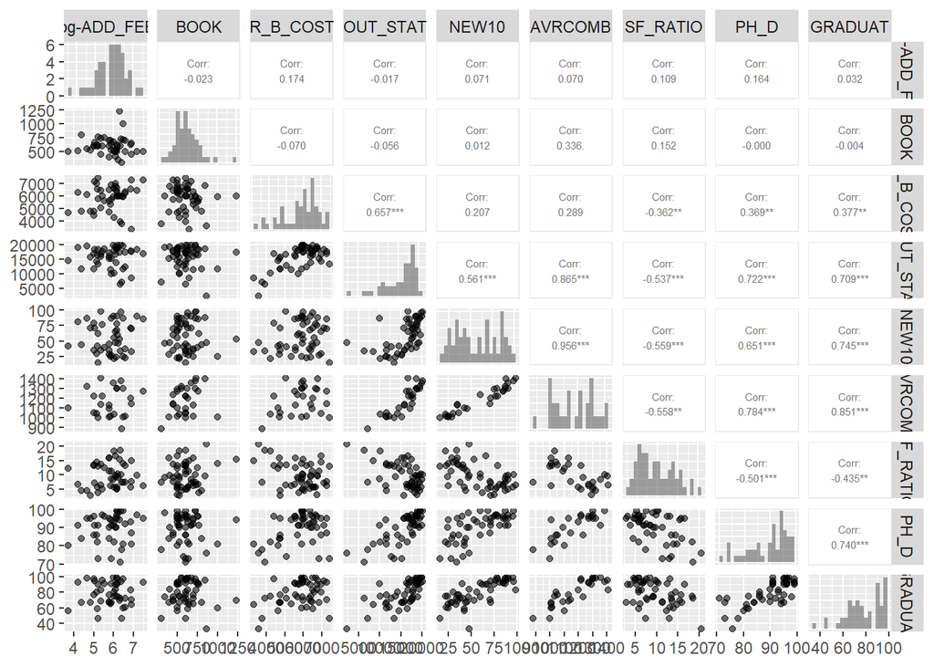

```r
ggpairs(col_split_mixed$private, aes(alpha = 0.5),
        diag = list(continuous = wrap("barDiag", bins = 20)),
        upper = list(continuous = wrap("cor", size = 2)))
```

Можно заметить, что NEW10/AVRCOMB разбивается на две части (поскольку AVRCOMB имеет много пропусков и сам AVRCOMB подразумевает разделение на подгруппы).

```r
col_I_sn[col_I_sn$PPIND=="private",]|>filter(NEW10<=50 & !is.na(AVRCOMB))|>rmarkdown::paged_table()
```

| ...1 | PPIND | FICE | STATE | TYPE | AVRMATH | AVRVERB | AVRCOMB | AVR_ACT | MATH_1 | MATH_3 | VERB_1 | VERB_3 | ACT_1 | ACT_3 | APP_REC | APP_ACC | NEW_STUD | NEW10 | NEW25 | FULLTIME | PARTTIME | IN_STATE | OUT_STAT | R_B_COST | ROOM | BOARD | ADD_FEE | BOOK | PERSONAL | … |
| --- | --- | --- | --- | --- | --- | --- | --- | --- | --- | --- | --- | --- | --- | --- | --- | --- | --- | --- | --- | --- | --- | --- | --- | --- | --- | --- | --- | --- | --- | --- |
| University of Southe | private | 1328 | CA | I | 592 | 498 | 1090 | 25 | 520 | 660 | 430 | 570 | 22 | 28 | 12229 | 8498 | 2477 | 45 | 71 | 13259 | 1429 | 17230 | 17230 | 6482 | 3566 | 2916 | 330 | 600 | 2210 | … |
| University of Denver | private | 1371 | CO | I | 540 | 470 | 1010 | 24 | 470 | 590 | 430 | 540 | 21 | 27 | 2974 | 2001 | 580 | 29 | 60 | 2666 | 554 | 15192 | 15192 | 4695 | 4695 | NA | 330 | 400 | 1350 | … |
| University of Delawa | private | 1431 | DE | I | NA | NA | 1035 | NA | 500 | 610 | 450 | 530 | NA | NA | 14446 | 10516 | 3252 | 22 | 57 | 14130 | 4522 | 3690 | 10220 | 4230 | 2280 | 1950 | 410 | 530 | 1300 | … |
| American University | private | 1434 | DC | I | 583 | 550 | 1133 | NA | 530 | 625 | 500 | 610 | NA | NA | 4613 | 3587 | 1048 | 35 | 77 | 4545 | 873 | 15934 | 15934 | 6400 | 2440 | 3960 | 210 | 450 | 800 | … |
| Illinois Institute o | private | 1691 | IL | I | 603 | 499 | 1102 | 25 | 540 | 670 | 440 | 560 | 22 | 28 | 1756 | 1360 | 478 | 42 | 77 | 1911 | 626 | 14550 | 14550 | 4620 | NA | NA | 40 | 500 | 700 | … |
| Loyola University Ch | private | 1710 | IL | I | 529 | 482 | 1011 | 24 | 470 | 590 | 430 | 540 | 21 | 26 | 3579 | 2959 | 868 | 25 | 55 | 5244 | 3417 | 11500 | 11500 | 5330 | NA | NA | 350 | 700 | 2000 | … |
| Northeastern Univers | private | 2199 | MA | I | 531 | 467 | 998 | 23 | 460 | 600 | 410 | 520 | 20 | 26 | 11901 | 8492 | 2517 | 16 | 42 | 11160 | 10221 | 13380 | 13380 | 7425 | 3990 | 3435 | 186 | 600 | 1750 | … |
| Clarkson University | private | 2699 | NY | I | 612 | 518 | 1130 | NA | 570 | 660 | 450 | 580 | NA | NA | 2174 | 1953 | 557 | 35 | 68 | 2332 | 53 | 15960 | 15960 | 5580 | 2622 | 2958 | 323 | 700 | 1300 | … |
| Fordham University | private | 2722 | NY | I | 535 | 506 | 1041 | NA | 490 | 610 | 460 | 580 | NA | NA | 4200 | 2874 | 942 | 30 | 55 | 4740 | 1646 | 14235 | 14235 | 6965 | 6965 | NA | 170 | 600 | 1735 | … |
| Hofstra University | private | 2732 | NY | I | 540 | 470 | 1010 | 24 | 480 | 590 | 430 | 560 | 23 | 27 | 7428 | 5860 | 1349 | 25 | 63 | 6534 | 1350 | 11600 | 11600 | 5920 | 3620 | 2300 | 650 | 1000 | 1000 | … |

[output cut: 2 more lines]

```r
col_I_sn[col_I_sn$PPIND=="private",]|>filter(NEW10>50 & !is.na(AVRCOMB))|>rmarkdown::paged_table()
```

| ...1 | PPIND | FICE | STATE | TYPE | AVRMATH | AVRVERB | AVRCOMB | AVR_ACT | MATH_1 | MATH_3 | VERB_1 | VERB_3 | ACT_1 | ACT_3 | APP_REC | APP_ACC | NEW_STUD | NEW10 | NEW25 | FULLTIME | PARTTIME | IN_STATE | OUT_STAT | R_B_COST | ROOM | BOARD | ADD_FEE | BOOK | PERSONAL | … |
| --- | --- | --- | --- | --- | --- | --- | --- | --- | --- | --- | --- | --- | --- | --- | --- | --- | --- | --- | --- | --- | --- | --- | --- | --- | --- | --- | --- | --- | --- | --- |
| California Institute | private | 1131 | CA | I | 750 | 660 | 1410 | NA | 740 | 780 | 610 | 700 | NA | NA | 1916 | 507 | 210 | 98 | NA | 912 | NA | 16695 | 16695 | 5051 | NA | NA | 210 | 735 | 3466 | … |
| Stanford University | private | 1305 | CA | I | 736 | 665 | 1401 | 31 | 650 | 750 | 580 | 690 | 26 | 33 | 13608 | 2926 | 1616 | 88 | 97 | 6573 | NA | 18669 | 18669 | 6795 | NA | NA | NA | 840 | 1355 | … |
| Emory University | private | 1564 | GA | I | 650 | 570 | 1220 | 28 | 600 | 700 | 530 | 610 | 26 | 30 | 8506 | 4168 | 1236 | 76 | 97 | 5544 | 192 | 17600 | 17600 | 6000 | 3600 | 2400 | 230 | 600 | 870 | … |
| Northwestern Univers | private | 1739 | IL | I | 670 | 600 | 1270 | 29 | 610 | 720 | 540 | 640 | 27 | 31 | 12289 | 5200 | 1902 | 85 | 98 | 7450 | 45 | 16404 | 16404 | 5520 | NA | NA | NA | 759 | 1585 | … |
| University of Notre | private | 1840 | IN | I | 650 | 570 | 1220 | NA | 620 | 720 | 540 | 640 | NA | NA | 7700 | 3700 | 1906 | 79 | 96 | 7671 | 30 | 16850 | 16850 | 4400 | 4400 | NA | 147 | 600 | 1350 | … |
| Johns Hopkins Univer | private | 2077 | MD | I | 686 | 606 | 1292 | 30 | 660 | 740 | 560 | 660 | NA | NA | 8474 | 3446 | 911 | 75 | 94 | 3566 | 1569 | 18800 | 18800 | 6740 | 3815 | 2925 | NA | 500 | 1040 | … |
| Massachusetts Instit | private | 2178 | MA | I | 742 | 639 | 1381 | 31 | 720 | 780 | 570 | 690 | 29 | 33 | 6411 | 2140 | 1078 | 96 | 99 | 4481 | 28 | 20100 | 20100 | 5975 | 3200 | 2775 | 600 | 725 | 1600 | … |
| Dartmouth College | private | 2573 | NH | I | 692 | 627 | 1319 | NA | 660 | 740 | 580 | 680 | NA | NA | 8587 | 2273 | 1087 | 87 | 99 | 3918 | 32 | 19545 | 19545 | 6070 | 3255 | 2815 | 105 | 550 | 1100 | … |
| Princeton University | private | 2627 | NJ | I | 708 | 647 | 1355 | NA | 645 | 737 | 583 | 678 | NA | NA | 13218 | 2042 | 1153 | 90 | 98 | 4540 | 146 | 19900 | 19900 | 5910 | 2696 | 3214 | 400 | 675 | 1575 | … |
| Columbia University | private | 2707 | NY | I | 680 | 620 | 1300 | NA | 630 | 720 | 590 | 680 | NA | NA | 6756 | 1930 | 871 | 78 | 96 | 3376 | 55 | 18624 | 18624 | 6664 | 3740 | 2924 | 486 | 550 | 300 | … |

[output cut: 6 more lines]

Среди частных университетов только один “Delaware University” имеет расхождения между IN_STATE и OUT_STAT. Сейчас идёт такое ценообразование. University of Delaware’s tuition is $15,410 for in-state and $37,930 for out-of-state.

```r
col_I_sn[col_I_sn$IN_STATE!=col_I_sn$OUT_STAT & col_I_sn$PPIND=="private",]
```

```
## # A tibble: 1 × 49
##   ...1     PPIND  FICE STATE TYPE  AVRMATH AVRVERB AVRCOMB AVR_ACT MATH_1 MATH_3
##   <chr>    <chr> <dbl> <chr> <chr>   <dbl>   <dbl>   <dbl>   <dbl>  <dbl>  <dbl>
## 1 Univers… priv…  1431 DE    I          NA      NA    1035      NA    500    610
## # ℹ 38 more variables: VERB_1 <dbl>, VERB_3 <dbl>, ACT_1 <dbl>, ACT_3 <dbl>,
## #   APP_REC <dbl>, APP_ACC <dbl>, NEW_STUD <dbl>, NEW10 <dbl>, NEW25 <dbl>,
## #   FULLTIME <dbl>, PARTTIME <dbl>, IN_STATE <dbl>, OUT_STAT <dbl>,
## #   R_B_COST <dbl>, ROOM <dbl>, BOARD <dbl>, ADD_FEE <dbl>, BOOK <dbl>,
## #   PERSONAL <dbl>, PH_D <dbl>, TERM_D <dbl>, SF_RATIO <dbl>, DONATE <dbl>,
## #   INSTRUCT <dbl>, GRADUAT <dbl>, SAL_FULL <dbl>, SAL_AC <dbl>, SAL_AS <dbl>,
## #   SAL_ALL <dbl>, COMP_FUL <dbl>, COMP_AC <dbl>, COMP_AS <dbl>, …
```

Public:

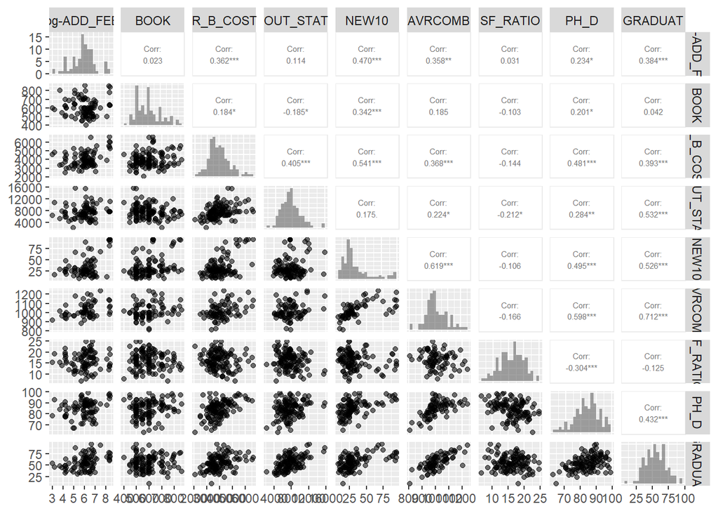

```r
ggpairs(col_split_mixed$public, aes(alpha = 0.5),
        diag = list(continuous = wrap("barDiag", bins = 20)),
        upper = list(continuous = wrap("cor", size = 2)))
```

Учитывая ограниченный объём данных, тем более после разделения по группам (например, наименьшая в private размера 29 без NA), следует воспользоваться pairwise. Более того, из-за признака AVRCOMB использование casewise неявно рассматривает корреляцию в другой подгруппе. Минусом pairwise является то, что из-за попарной проверки могут учитываться данные, пропущенные в других парах.

```r
compute_corr <- function(group_data) {
  corr_pairwise_pearson <- cor(group_data, use = "pairwise.complete.obs", method = "pearson")
  corr_pairwise_spearman <- cor(group_data, use = "pairwise.complete.obs", method = "spearman")
  return(list(pairwise_pearson = corr_pairwise_pearson, pairwise_spearman = corr_pairwise_spearman))
}

make_corr_plots <- function(corr_list, group) {
  p1 <- ggcorrplot(corr_list$pairwise_pearson,
                   lab = TRUE,
                   lab_size = 1.9,
                   colors = c("blue", "white", "red"),
                   title = paste("Pairwise Cor Pearson Matrix for Group", group),
                   ggtheme = theme_minimal() +
                     theme(plot.title = element_text(size = 6)) # Reduced title size
  )
  p2 <- ggcorrplot(corr_list$pairwise_spearman,
                   lab = TRUE,
                   lab_size = 1.9,
                   colors = c("blue", "white", "red"),
                   title = paste("Pairwise Cor Spearman Matrix for Group", group),
                   ggtheme = theme_minimal() +
                     theme(plot.title = element_text(size = 6)) # Reduced title size
  )
  grid.arrange(p1, p2, ncol = 2, widths = c(4, 4),  # Adjust widths here
               padding = unit(1, "cm"))  # Add padding for extra space
}
```

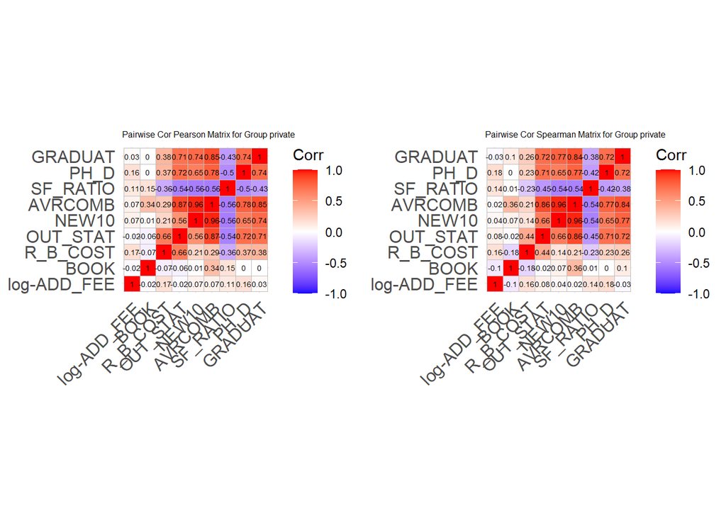

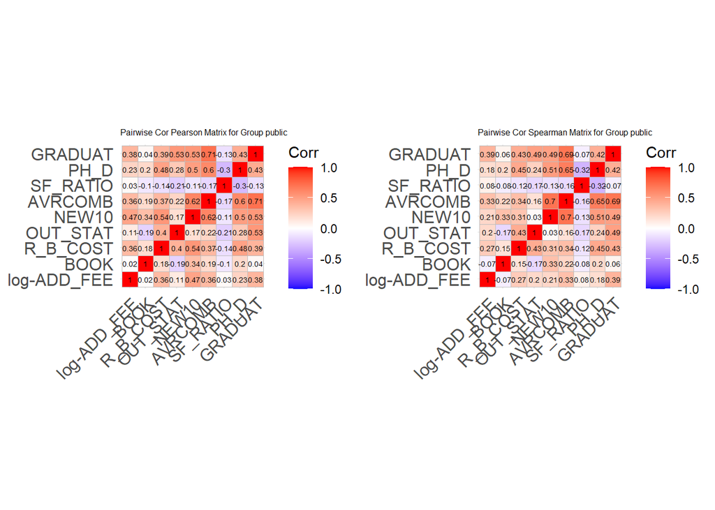

```r
library(ggcorrplot)
for (group in names(col_split_mixed)) {
    group_data <- col_split_mixed[[group]]
    cor_matrix <- compute_corr(group_data)
    plot_pearson_spearman <- make_corr_plots(cor_matrix, group)
    print(plot_pearson_spearman)
}
```

В тех ячейках, где совпадают или близки коэффициенты корреляции Пирсона и Спирмена почти нет выбросов и у scatterplot эллиптическая структура, если Пирсон значительно больше Спирмена - есть заметные выбросы. Спирмен может быть больше Пирсона, если выбросы имеются, но их положение не очень значимо относительно других наблюдений.

Замечаем блок GRADUAT, PH_D, SF_RATIO, AVRCOMB, NEW10, OUT_STAT в private. В public заметные, но менее выраженные зависимости.

Можно сказать, что в private (AVRCOMB - NEW10) AVRCOMB линейно зависит от NEW10 (% студентов, входящих в топ %10 старшей школы).

Рассмотрим несколько примеров с частной корреляцией в private и в public

Private:

Корреляции между AVRCOMB, BOOK велика, хотя BOOK может входить в OUT_STAT (но они некоррелируют) также непонятна корреляция между R_B_COST и SF_RATIO (возможно OUT_STAT - скрытый фактор).

Для R_B_COST и SF_RATIO выберем следующие скрытые факторы:

- OUT_STAT - стоимость обучения связана с ценой проживания R_B_COST и качеством образования, что влияет на SF_RATIO.

Поставим уровень значимости alpha = 0.05

```r
res<-pcor(col_split_mixed$private[,c("R_B_COST", "SF_RATIO", "OUT_STAT")])
res$estimate["R_B_COST", "SF_RATIO"]
```

```
## [1] -0.01433506
```

```r
res$p.value["R_B_COST", "SF_RATIO"]
```

```
## [1] 0.9196585
```

estimate - получившаяся частная корреляция. Замечаем, что без OUT_STAT коэффициент корреляции Пирсона близок к 0, а p-value ~ 0.90.

- Для AVRCOMB/BOOK можно выделить OUT_STAT по тем же причинам, что и в предыдущем примере и NEW10, так как они влияют на AVRCOMB

```r
group_1<-c("AVRCOMB", "BOOK")
res<-pcor(na.omit(col_split_mixed$private[,c(group_1, "NEW10")]))
res
```

```
## $estimate
##           AVRCOMB        BOOK       NEW10
## AVRCOMB 1.0000000  0.15177454  0.95475775
## BOOK    0.1517745  1.00000000 -0.09376246
## NEW10   0.9547577 -0.09376246  1.00000000
##
## $p.value
##              AVRCOMB      BOOK        NEW10
## AVRCOMB 0.000000e+00 0.4498169 1.122411e-14
## BOOK    4.498169e-01 0.0000000 6.418045e-01
## NEW10   1.122411e-14 0.6418045 0.000000e+00
##
## $statistic
##            AVRCOMB       BOOK      NEW10
## AVRCOMB  0.0000000  0.7677672 16.0525714
## BOOK     0.7677672  0.0000000 -0.4708868
## NEW10   16.0525714 -0.4708868  0.0000000
##
## $n
## [1] 28
##
## $gp
## [1] 1
##
## $method
## [1] "pearson"
```

```r
res_2<-pcor(na.omit(col_split_mixed$private[,c(group_1, "OUT_STAT", "NEW10")]))
res_2
```

```
## $estimate
##            AVRCOMB        BOOK   OUT_STAT      NEW10
## AVRCOMB  1.0000000  0.23482510  0.2604398 0.81612411
## BOOK     0.2348251  1.00000000 -0.3815662 0.02045576
## OUT_STAT 0.2604398 -0.38156623  1.0000000 0.27217396
## NEW10    0.8161241  0.02045576  0.2721740 1.00000000
##
## $p.value
##               AVRCOMB       BOOK   OUT_STAT        NEW10
## AVRCOMB  0.000000e+00 0.24820290 0.19879665 3.728780e-07
## BOOK     2.482029e-01 0.00000000 0.05442782 9.209917e-01
## OUT_STAT 1.987966e-01 0.05442782 0.00000000 1.785854e-01
## NEW10    3.728780e-07 0.92099170 0.17858544 0.000000e+00
##
## $statistic
##           AVRCOMB       BOOK  OUT_STAT     NEW10
## AVRCOMB  0.000000  1.1834967  1.321494 6.9187347
## BOOK     1.183497  0.0000000 -2.022288 0.1002333
## OUT_STAT 1.321494 -2.0222884  0.000000 1.3856870
## NEW10    6.918735  0.1002333  1.385687 0.0000000
##
## $n
## [1] 28
##
## $gp
## [1] 2
##
## $method
## [1] "pearson"
```

Получаем, что частная корреляция AVRCOMB/BOOK больше зависит от NEW10, чем от NEW10/OUT_STAT.

Public:

- Зависимость между GRADUAT и R_B_COST. Скрытые факторы: OUT_STAT и NEW10.

```r
group_2<-c("GRADUAT", "R_B_COST")
res_1<-pcor(na.omit(col_split_mixed$public[,c(group_2, "OUT_STAT", "NEW10")]), method = "spearman")
res_1
```

```
## $estimate
##            GRADUAT  R_B_COST   OUT_STAT      NEW10
## GRADUAT  1.0000000 0.1228687  0.4375959  0.4975827
## R_B_COST 0.1228687 1.0000000  0.2919737  0.2007210
## OUT_STAT 0.4375959 0.2919737  1.0000000 -0.2953932
## NEW10    0.4975827 0.2007210 -0.2953932  1.0000000
##
## $p.value
##               GRADUAT    R_B_COST     OUT_STAT        NEW10
## GRADUAT  0.000000e+00 0.216289869 3.797030e-06 8.929736e-08
## R_B_COST 2.162899e-01 0.000000000 2.766667e-03 4.205514e-02
## OUT_STAT 3.797030e-06 0.002766667 0.000000e+00 2.451802e-03
## NEW10    8.929736e-08 0.042055136 2.451802e-03 0.000000e+00
##
## $statistic
##           GRADUAT R_B_COST  OUT_STAT     NEW10
## GRADUAT  0.000000 1.244243  4.890929  5.764986
## R_B_COST 1.244243 0.000000  3.067983  2.059128
## OUT_STAT 4.890929 3.067983  0.000000 -3.107327
## NEW10    5.764986 2.059128 -3.107327  0.000000
##
## $n
## [1] 105
##
## $gp
## [1] 2
##
## $method
## [1] "spearman"
```

Коэффициент корреляции Спирмена понизился, p-value ~ 0.22. Не отвергаем влияния совокупности скрытых факторов OUT_STAT и NEW10.

- Коэффициент корреляции Спирмена OUT_STAT и PH_D равен 0.24, хотя визуально кажется, что они коррелируют сильнее. Скрытыми факторами могут быть NEW10, так как NEW10 отражает престижность вузов (NEW10 может зависеть от PH_D, поскольку лучшие студенты хотят найти лучших преподавателей), а OUT_STAT зависит от NEW10 и PH_D.

```r
group_3<-c("PH_D", "OUT_STAT")
res_3<-pcor(na.omit(col_split_mixed$public[,c(group_3, "NEW10")]), method = "spearman")
res_3
```

```
## $estimate
##               PH_D    OUT_STAT       NEW10
## PH_D     1.0000000  0.16610803  0.50812933
## OUT_STAT 0.1661080  1.00000000 -0.04604289
## NEW10    0.5081293 -0.04604289  1.00000000
##
## $p.value
##                  PH_D   OUT_STAT        NEW10
## PH_D     0.000000e+00 0.09520736 4.987348e-08
## OUT_STAT 9.520736e-02 0.00000000 6.458585e-01
## NEW10    4.987348e-08 0.64585848 0.000000e+00
##
## $statistic
##              PH_D   OUT_STAT      NEW10
## PH_D     0.000000  1.6844818  5.8996943
## OUT_STAT 1.684482  0.0000000 -0.4609178
## NEW10    5.899694 -0.4609178  0.0000000
##
## $n
## [1] 103
##
## $gp
## [1] 1
##
## $method
## [1] "spearman"
```

Не отвергаем влияние NEW10 на PH_D и OUT_STAT. Можно также рассмотреть частную корреляцию от SF_RATIO, так как это отражает (неявно) процент PH_D и стоимость OUT_STAT за счёт студентов и профессоров.

```r
res_4<-pcor(na.omit(col_split_mixed$public[,c(group_3, "SF_RATIO")]), method = "spearman")
res_4
```

```
## $estimate
##                PH_D    OUT_STAT    SF_RATIO
## PH_D      1.0000000  0.20532911 -0.27979699
## OUT_STAT  0.2053291  1.00000000 -0.09968463
## SF_RATIO -0.2797970 -0.09968463  1.00000000
##
## $p.value
##                 PH_D   OUT_STAT    SF_RATIO
## PH_D     0.000000000 0.02702694 0.002351145
## OUT_STAT 0.027026942 0.00000000 0.287028174
## SF_RATIO 0.002351145 0.28702817 0.000000000
##
## $statistic
##               PH_D  OUT_STAT  SF_RATIO
## PH_D      0.000000  2.240044 -3.111698
## OUT_STAT  2.240044  0.000000 -1.069669
## SF_RATIO -3.111698 -1.069669  0.000000
##
## $n
## [1] 117
##
## $gp
## [1] 1
##
## $method
## [1] "spearman"
```

Отвергаем влияние SF_RATIO как скрытого фактора. Не отвергаем, что PH_D скрытый фактор относительно SF_RATIO/OUT_STAT.

### Выводы:

- Pairwise или Casewise? Выбран pairwise, поскольку casewise убирает большую часть данных и выделяет новую подгруппу.
- Матрицы корреляций public и private: отличаются. В public заметно больше коррелирующих факторов, что вероятно, связано с скрытыми факторами. В случае private явно выделяется группа признаков GRADUAT, PH_D, SF_RATIO, AVRCOMB, NEW10 и OUT_STAT, R_B_COST.
- Частные корреляции:
- public:
- PH_D, OUT_STAT - скрытый фактор NEW10
- GRADUAT, R_B_COST - скрытые факторы OUT_STAT/NEW10
- private:
- R_B_COST, SF_RATIO - скрытый фактор OUT_STAT
- AVRCOMB, BOOK - скрытый фактор NEW10